# Fertility & Development - How do education and infrastructure affect fertility?

## 1) Introduction

#### In the following, the fertil2 dataset from the wooldridge package is used to test assumptions of development economics. Precisely, it will be observed how different socioeconomic factors influence fertility. Eventually, an ML model will be trained to predict “ever born children” (= fertility) based on a set of independent variables.

## 2) Libraries

```r
library(tidyverse)
```

```r
library(ggplot2)
library(caret)
library(wooldridge)
library(randomForest)
library(glmnet)
```

## 3) Data

```r
df <- fertil2
head(df)
```

```
##   mnthborn yearborn age electric radio tv bicycle educ ceb agefbrth children
## 1        5       64  24        1     1  1       1   12   0       NA        0
## 2        1       56  32        1     1  1       1   13   3       25        3
## 3        7       58  30        1     0  0       0    5   1       27        1
## 4       11       45  42        1     0  1       0    4   3       17        2
## 5        5       45  43        1     1  1       1   11   2       24        2
## 6        8       52  36        1     0  0       0    7   1       26        1
##   knowmeth usemeth monthfm yearfm agefm idlnchld heduc agesq urban urb_educ
## 1        1       0      NA     NA    NA        2    NA   576     1       12
## 2        1       1      11     80    24        3    12  1024     1       13
## 3        1       0       6     83    24        5     7   900     1        5
## 4        1       0       1     61    15        3    11  1764     1        4
## 5        1       1       3     66    20        2    14  1849     1       11
## 6        1       1      11     76    24        4     9  1296     1        7
##   spirit protest catholic frsthalf educ0 evermarr
## 1      0       0        0        1     0        0
## 2      0       0        0        1     0        1
## 3      1       0        0        0     0        1
## 4      0       0        0        0     0        1
## 5      0       1        0        1     0        1
## 6      0       0        0        0     0        1
```

```r
df <- df %>% na.omit()
summary(df)
```

```
##     mnthborn         yearborn          age           electric
##  Min.   : 1.000   Min.   :38.00   Min.   :17.00   Min.   :0.0000
##  1st Qu.: 3.000   1st Qu.:50.00   1st Qu.:26.00   1st Qu.:0.0000
##  Median : 6.000   Median :56.00   Median :31.00   Median :0.0000
##  Mean   : 6.158   Mean   :55.56   Mean   :32.29   Mean   :0.1745
##  3rd Qu.: 9.000   3rd Qu.:62.00   3rd Qu.:38.00   3rd Qu.:0.0000
##  Max.   :12.000   Max.   :71.00   Max.   :49.00   Max.   :1.0000
##      radio              tv            bicycle            educ
##  Min.   :0.0000   Min.   :0.0000   Min.   :0.0000   Min.   : 0.000
##  1st Qu.:0.0000   1st Qu.:0.0000   1st Qu.:0.0000   1st Qu.: 0.000
##  Median :1.0000   Median :0.0000   Median :0.0000   Median : 6.000
##  Mean   :0.7091   Mean   :0.1257   Mean   :0.3083   Mean   : 5.168
##  3rd Qu.:1.0000   3rd Qu.:0.0000   3rd Qu.:1.0000   3rd Qu.: 7.000
##  Max.   :1.0000   Max.   :1.0000   Max.   :1.0000   Max.   :20.000
##       ceb            agefbrth        children         knowmeth
##  Min.   : 1.000   Min.   :10.00   Min.   : 0.000   Min.   :0.0000
##  1st Qu.: 2.000   1st Qu.:17.00   1st Qu.: 2.000   1st Qu.:1.0000
##  Median : 3.000   Median :19.00   Median : 3.000   Median :1.0000
##  Mean   : 3.911   Mean   :19.18   Mean   : 3.632   Mean   :0.9686
##  3rd Qu.: 5.000   3rd Qu.:21.00   3rd Qu.: 5.000   3rd Qu.:1.0000
##  Max.   :13.000   Max.   :38.00   Max.   :13.000   Max.   :1.0000
##     usemeth          monthfm           yearfm         agefm
##  Min.   :0.0000   Min.   : 1.000   Min.   :53.0   Min.   :10.0
##  1st Qu.:0.0000   1st Qu.: 3.000   1st Qu.:72.0   1st Qu.:17.0
##  Median :1.0000   Median : 6.000   Median :78.0   Median :20.0
##  Mean   :0.6818   Mean   : 6.257   Mean   :76.7   Mean   :20.7
##  3rd Qu.:1.0000   3rd Qu.: 9.000   3rd Qu.:83.0   3rd Qu.:23.0
##  Max.   :1.0000   Max.   :12.000   Max.   :88.0   Max.   :46.0
##     idlnchld         heduc            agesq          urban
##  Min.   : 0.00   Min.   : 0.000   Min.   : 289   Min.   :0.0000
##  1st Qu.: 4.00   1st Qu.: 0.000   1st Qu.: 676   1st Qu.:0.0000
##  Median : 5.00   Median : 6.000   Median : 961   Median :1.0000
##  Mean   : 5.26   Mean   : 5.259   Mean   :1099   Mean   :0.5375
##  3rd Qu.: 6.00   3rd Qu.: 9.000   3rd Qu.:1444   3rd Qu.:1.0000
##  Max.   :20.00   Max.   :20.000   Max.   :2401   Max.   :1.0000
##     urb_educ          spirit          protest          catholic
##  Min.   : 0.000   Min.   :0.0000   Min.   :0.0000   Min.   :0.0000
##  1st Qu.: 0.000   1st Qu.:0.0000   1st Qu.:0.0000   1st Qu.:0.0000
##  Median : 0.000   Median :0.0000   Median :0.0000   Median :0.0000
##  Mean   : 3.432   Mean   :0.4334   Mean   :0.2199   Mean   :0.1053
##  3rd Qu.: 7.000   3rd Qu.:1.0000   3rd Qu.:0.0000   3rd Qu.:0.0000
##  Max.   :20.000   Max.   :1.0000   Max.   :1.0000   Max.   :1.0000
##     frsthalf         educ0           evermarr
##  Min.   :0.000   Min.   :0.0000   Min.   :1
##  1st Qu.:0.000   1st Qu.:0.0000   1st Qu.:1
##  Median :1.000   Median :0.0000   Median :1
##  Mean   :0.566   Mean   :0.2688   Mean   :1
##  3rd Qu.:1.000   3rd Qu.:1.0000   3rd Qu.:1
##  Max.   :1.000   Max.   :1.0000   Max.   :1
```

## 4) Random seed and train-test split in 80-20 ratio

```r
set.seed(123)
train_index <- createDataPartition(df$ceb, p = 0.8, list = F)
train_data <- df[train_index, ]
test_data <- df[-train_index, ]
```

## 5) Model Training

```r
nzv <- nearZeroVar(train_data, saveMetrics = TRUE)
print(nzv)
```

```
##          freqRatio percentUnique zeroVar   nzv
## mnthborn  1.416058    0.87145969   FALSE FALSE
## yearborn  1.012658    2.46913580   FALSE FALSE
## age       1.012658    2.39651416   FALSE FALSE
## electric  4.597561    0.14524328   FALSE FALSE
## radio     2.425373    0.14524328   FALSE FALSE
## tv        6.524590    0.14524328   FALSE FALSE
## bicycle   2.224824    0.14524328   FALSE FALSE
## educ      1.242525    1.52505447   FALSE FALSE
## ceb       1.092827    0.94408134   FALSE FALSE
## agefbrth  1.120370    1.81554103   FALSE FALSE
## children  1.068548    1.01670298   FALSE FALSE
## knowmeth 34.307692    0.14524328   FALSE  TRUE
## usemeth   2.129545    0.14524328   FALSE FALSE
## monthfm   1.155405    0.87145969   FALSE FALSE
## yearfm    1.012821    2.54175744   FALSE FALSE
## agefm     1.078740    2.46913580   FALSE FALSE
## idlnchld  1.312292    1.23456790   FALSE FALSE
## heduc     1.685315    1.52505447   FALSE FALSE
## agesq     1.012658    2.39651416   FALSE FALSE
## urban     1.175355    0.14524328   FALSE FALSE
## urb_educ  4.079787    1.52505447   FALSE FALSE
## spirit    1.329949    0.14524328   FALSE FALSE
## protest   3.330189    0.14524328   FALSE FALSE
## catholic  8.629371    0.14524328   FALSE FALSE
## frsthalf  1.291181    0.14524328   FALSE FALSE
## educ0     2.681818    0.14524328   FALSE FALSE
## evermarr  0.000000    0.07262164    TRUE  TRUE
```

```r
formula <- ceb ~ urban*educ + poly(age, 2) + urban*electric + agefbrth + agefm + educ*heduc + spirit + protest + catholic

ctrl <- trainControl(
  method = "repeatedcv",
  number = 10,
  repeats = 3
)

grid <- expand.grid(
  alpha  = seq(0, 1, length.out = 11),
  lambda = 10 ^ seq(-3, 1, length.out = 30)
)

rf_grid <- expand.grid(
  mtry = c(2,4,6,8,10)
)

# First model
dev_model_glmnet <- train(
  formula,
  data = train_data,
  method = "glmnet",
  trControl = ctrl,
  preProcess = c("center", "scale", "medianImpute"),
  tuneGrid = grid,
  metric = "RMSE"
)
# Second model
dev_model_poisson <- train(
  formula,
  data = train_data,
  method = "glm",
  family = "poisson",
  trControl = ctrl
)
```

```r
prediction <- predict(dev_model_glmnet, newdata = test_data)
pred_poisson <- predict(dev_model_poisson, newdata = test_data)

results <- data.frame(
  Actual = test_data$ceb,
  Predicted = prediction,
  Predicted_Poisson = pred_poisson
)

rmse <- sqrt(mean((results$Actual - results$Predicted)^2))
rmse_poisson <- sqrt(mean((results$Actual - results$Predicted_Poisson)^2))
print(paste("RMSE: ", rmse))
```

```
## [1] "RMSE:  1.5801192103796"
```

```r
print(paste("RMSE_Poisson: ", rmse_poisson))
```

```
## [1] "RMSE_Poisson:  1.56268736581785"
```

```r
print(results)
```

```
##      Actual    Predicted Predicted_Poisson
## 2         3  1.848829871         2.1454029
## 3         1  1.541425466         2.0666724
## 7         4  3.533082746         3.2082331
## 11        3  3.223637517         2.8301452
## 27        6  4.609180649         4.1657980
## 41        1  1.900698551         2.2050718
## 60        1  3.885756145         3.6429071
## 62        5  3.806138408         3.6077560
## 74        2  5.351103728         4.4695245
## 76        2  2.620322574         2.1949348
## 100       6  4.974391914         4.7319418
## 111       1  3.932016244         3.8729661
## 117       3  2.482220089         2.3501844
## 142       2  4.207914921         3.8366919
```

[output cut: 328 more lines]

## 6) Female Education vs. Fertility

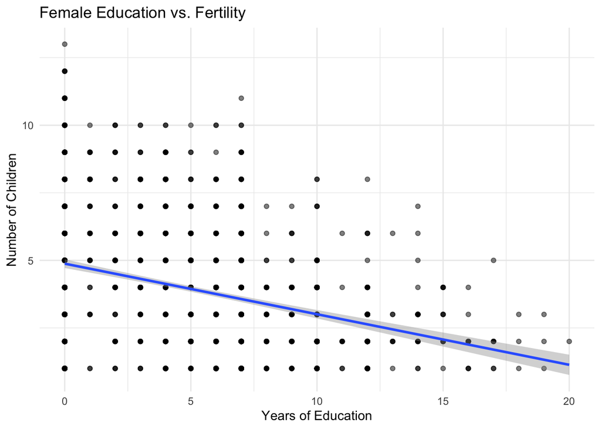

```r
ggplot(df, aes(x = educ, y = ceb)) +
  geom_point(alpha = 0.5) +
  geom_smooth(method = "lm") +
  labs(
    title = "Female Education vs. Fertility",
    x = "Years of Education",
    y = "Number of Children"
  ) +
  theme_minimal()
```

```r
lm1 <- lm(ceb ~ educ, data = df)
summary(lm1)
```

```
##
## Call:
## lm(formula = ceb ~ educ, data = df)
##
## Residuals:
##     Min      1Q  Median      3Q     Max
## -3.8782 -1.5682 -0.1938  1.1511  8.1218
##
## Coefficients:
##             Estimate Std. Error t value Pr(>|t|)
## (Intercept)  4.87823    0.08278   58.93   <2e-16 ***
## educ        -0.18715    0.01239  -15.11   <2e-16 ***
## ---
## Signif. codes:  0 '***' 0.001 '**' 0.01 '*' 0.05 '.' 0.1 ' ' 1
##
## Residual standard error: 2.175 on 1717 degrees of freedom
## Multiple R-squared:  0.1173, Adjusted R-squared:  0.1168
## F-statistic: 228.2 on 1 and 1717 DF,  p-value: < 2.2e-16
```

#### It is the textbook assumption of development economics, that as female education increases fertility rates drop. The graphic and accompanying linear regression confirm that assumption.

## 7) Fertility in Urban vs. Rural Areas

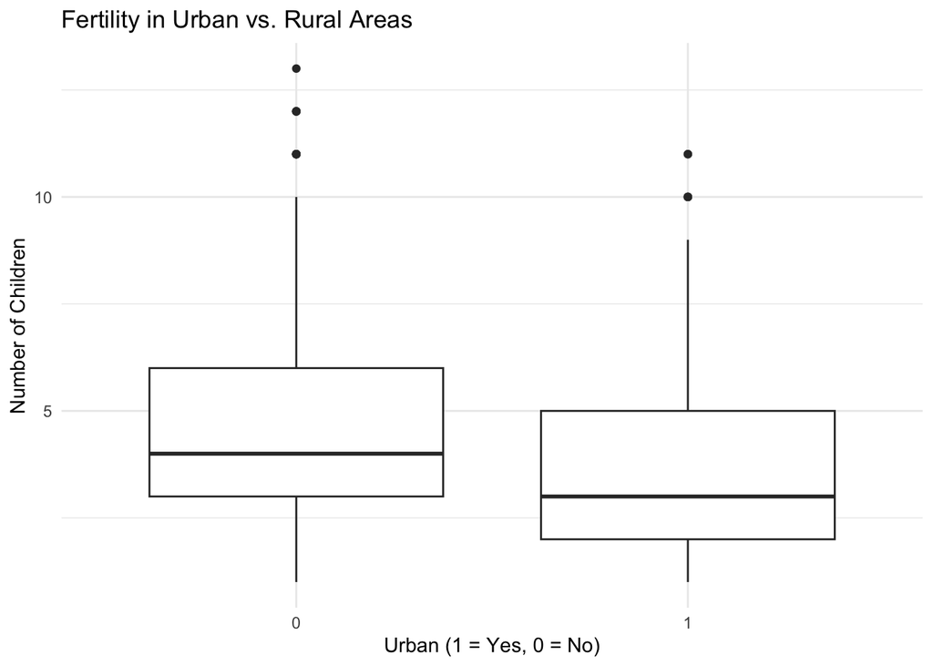

```r
ggplot(df, aes(x = factor(urban), y = ceb)) +
  geom_boxplot() +
  labs(
    title = "Fertility in Urban vs. Rural Areas",
    x = "Urban (1 = Yes, 0 = No)",
    y = "Number of Children"
  ) +
  theme_minimal()
```

```r
t.test(ceb ~ urban, data = df)
```

```
##
##  Welch Two Sample t-test
##
## data:  ceb by urban
## t = 9.7697, df = 1582.1, p-value < 2.2e-16
## alternative hypothesis: true difference in means between group 0 and group 1 is not equal to 0
## 95 percent confidence interval:
##  0.8598821 1.2918944
## sample estimates:
## mean in group 0 mean in group 1
##        4.489308        3.413420
```

## 8) ML model results

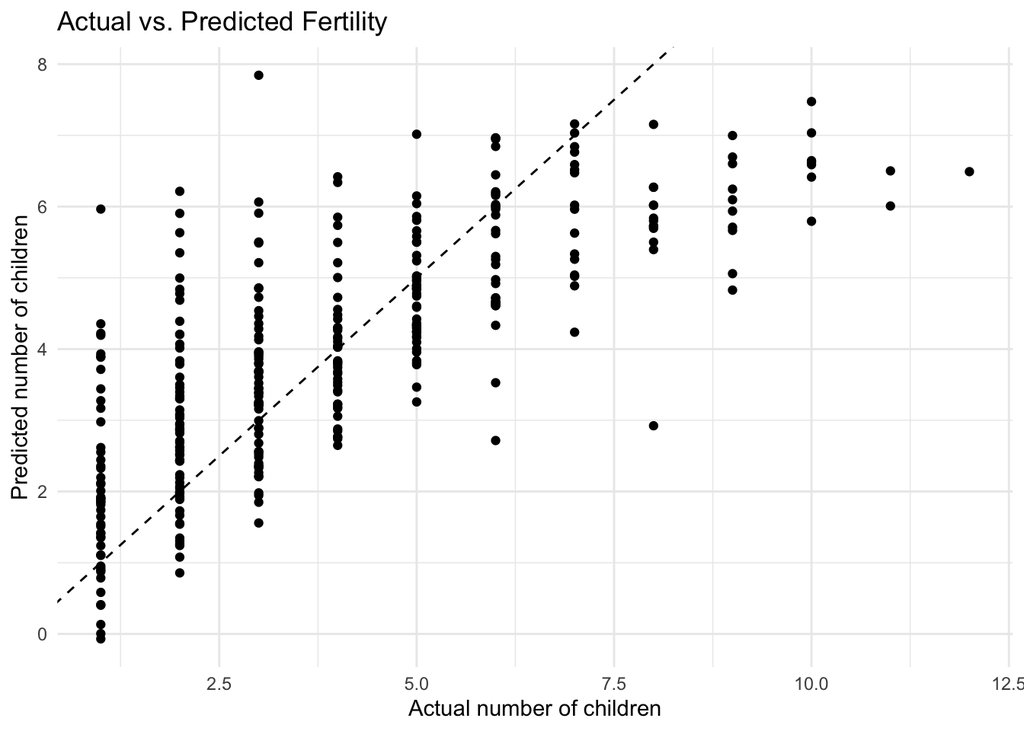

```r
ggplot(results, aes(x = Actual, y = Predicted)) +
  geom_point() +
  geom_abline(slope = 1, intercept = 0, linetype = "dashed") +
  labs(
    title = "Actual vs. Predicted Fertility",
    x = "Actual number of children",
    y = "Predicted number of children"
  ) +
  theme_minimal()
```

## 9) Comparison to baseline assumption

```r
print(paste("RMSE: ", rmse))
```

```
## [1] "RMSE:  1.5801192103796"
```

```r
print(paste("RMSE_Poisson: ", rmse_poisson))
```

```
## [1] "RMSE_Poisson:  1.56268736581785"
```

```r
print(paste("SD(ceb): ", sd(df$ceb)))
```

```
## [1] "SD(ceb):  2.31452645520565"
```

#### The Poisson model’s RMSE equals 1.56, i.e. on average the model is off by 1.56 “ever born children”. Given the complex social, cultural and economic factors that influence fertility, the model has a moderate level of predictive accuracy, but also highlights important unexplained variation. The standard deviation of the dependent variable (ceb) is 2.31. This indicates that the model performs better than a naive baseline prediction that just guesses the mean number of ever born children for all observations.